# Lec 08: Logistic Regression

MATH 456 - Spring 2016

# Assigned Reading and additional references

- Open Intro Section 8.4
- Afifi Ch 12 (selected)
- Article: When can odds ratios mislead? http://www.ncbi.nlm.nih.gov/pmc/articles/PMC1112884/

– Additional References

- http://www.ats.ucla.edu/stat/sas/faq/oratio.htm

# Introduction

- Logistic regression is a tool used to model a categorical outcome variable with two levels: Y = 1 if event, = 0 if no event.
- Instead of modeling the outcome directly $E(Y|X)$ as with linear regression, we model the probability of an event occurring: $P(Y=1|X)$.

## Uses of Logistic Regression (Afifi 12.10)

- Assess the impact selected covariates have on the probability of an outcome occurring.
- Predict the likelihood / chance / probability of an event occurring given a certain covariate pattern.

# The Logistic Regression Model (Afifi 12.4)

Let $p_{i} = P(y_{i}=1)$.

The logistic model relates the probability of an event based on a linear combination of X’s.

$log\left( \frac{p_{i}}{1-p_{i}} \right) = \beta_{0} + \beta_{1}x_{1i} + \beta_{2}x_{2i} + \ldots + \beta_{p}x_{pi}$

Since the *odds* are defined as the probability an event occurs divided by the probability it does not occur: $(p/(1-p))$, the function $log\left(\frac{p_{i}}{1-p_{i}}\right)$ is also known as the *log odds*, or more commonly called the *logit*.

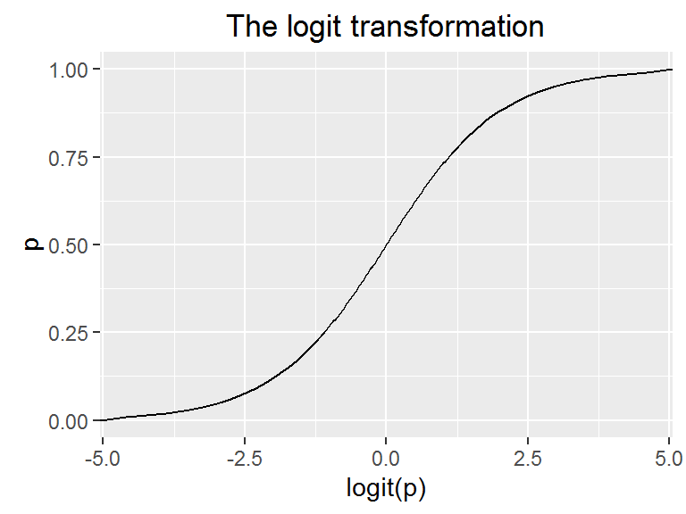

```r
p <- seq(0, 1, by=.01)
logit.p <- log(p/(1-p))
qplot(logit.p, p, geom="line", xlab = "logit(p)", main="The logit transformation")
```

This in essence takes a binary outcome 0/1 variable, turns it into a continuous probability (which only has a range from 0 to 1) Then the logit(p) has a continuous distribution ranging from $-\infty$ to $\infty$, which is the same form as a Multiple Linear Regression (continuous outcome modeled on a set of covariates)

## Modeling the probability of an event.

Back solving the logistic model for $p_{i} = e^{\beta X} / (1+e^{\beta X})$:

$p_{i} = \frac{e^{\beta_{0} + \beta_{1}x_{1i} + \beta_{2}x_{2i} + \ldots + \beta_{p}x_{pi}}} {1 + e^{\beta_{0} + \beta_{1}x_{1i} + \beta_{2}x_{2i} + \ldots + \beta_{p}x_{pi}}}$

## Logistic Regression via GLM in R

A logistic regression model can be fit in R using the `glm()` function. GLM stands for Generalized Linear Model. GLM’s can fit an entire *family* of distributions and can be thought of as $E(Y|X) = C(X)$ where $C$ is a **link** function that relates $Y$ to $X$.

- Linear regression: C = Identity function (no change)
- Logistic regression: C = logit function
- Poisson regression: C = log function

The outcome $y$ is a 0/1 Bernoulli random variable. The sum of a vector of Bernoulli’s ($\sum_{i=1}^{n}y_{i}$) has a Binomial distribution. When we specify that `family = "binomial"` the `glm()` function auto-assigns a “logit” link function. See `?family` for more information on this.

```r
glm(y ~ x1 + x2 + x3, data=DATA, family="binomial")
```

# Example: Gender effects on Depression

```r
depress <- read.delim("C:/GitHub/MATH456/data/depress_030816.txt")
names(depress) <- tolower(names(depress)) # make all variable names lower case.
depress$sex <- depress$sex -1 # Refactor to match book table.
```

## Using a two-way table.

Examine the two-way table of gender by depression and calculate the Odds Ratio for depression and gender.

```r
table(depress$sex, depress$cases, dnn = c("Gender", "Depression"))
```

```
##       Depression
## Gender   0   1
##      0 101  10
##      1 143  40
```

Recall that the `epi.2by2` function in the `epiR` package required the (1,1) cell to be in the upper left corner. That is not default table orientation for R. So here is a helper function `rotate()` that I found on [StackOverflow](http://stackoverflow.com/questions/16496210/rotate-a-matrix-in-r) that will rotate the matrix to the proper orientation.

```r
rotate <- function(x) t(apply(t(apply(x, 2, rev)), 2, rev))
```

Create the table object, rotate it (to confirm it works), and call `epi.2by2` to calculate the OR and corresponding CI.

```r
library(epiR)
dep_sex_xtab <- table(depress$sex, depress$cases)
rotate(dep_sex_xtab)
```

```
##
##      1   0
##   1 40 143
##   0 10 101
```

```r
epi.2by2(rotate(dep_sex_xtab))
```

```
##              Outcome +    Outcome -      Total        Inc risk *
## Exposed +           40          143        183             21.86
## Exposed -           10          101        111              9.01
## Total               50          244        294             17.01
##                  Odds
## Exposed +       0.280
## Exposed -       0.099
## Total           0.205
##
## Point estimates and 95 % CIs:
## -------------------------------------------------------------------
## Inc risk ratio                               2.43 (1.26, 4.65)
## Odds ratio                                   2.83 (1.35, 5.91)
## Attrib risk *                                12.85 (4.83, 20.86)
## Attrib risk in population *                  8.00 (1.16, 14.84)
## Attrib fraction in exposed (%)               58.78 (20.92, 78.52)
## Attrib fraction in population (%)            47.03 (10.63, 68.60)
## -------------------------------------------------------------------
##  X2 test statistic: 8.082 p-value: 0.004
##  Wald confidence limits
##  * Outcomes per 100 population units
```

Females have 2.83 times the odds of being depressed compared to males (95% CI 1.35, 5.91).

## Using Logistic Regression

We will come to the same conclusion by running a logistic regression model,

```r
dep_sex_model <- glm(cases ~ sex, data=depress, family="binomial")
summary(dep_sex_model)
```

```
##
## Call:
## glm(formula = cases ~ sex, family = "binomial", data = depress)
##
## Deviance Residuals:
##     Min       1Q   Median       3Q      Max
## -0.7023  -0.7023  -0.4345  -0.4345   2.1941
##
## Coefficients:
##             Estimate Std. Error z value Pr(>|z|)
## (Intercept)  -2.3125     0.3315  -6.976 3.04e-12 ***
## sex           1.0386     0.3767   2.757  0.00583 **
## ---
## Signif. codes:  0 '***' 0.001 '**' 0.01 '*' 0.05 '.' 0.1 ' ' 1
##
## (Dispersion parameter for binomial family taken to be 1)
##
##     Null deviance: 268.12  on 293  degrees of freedom
## Residual deviance: 259.40  on 292  degrees of freedom
## AIC: 263.4
##
## Number of Fisher Scoring iterations: 5
```

and exponentiating the coefficients.

```r
exp(coef(dep_sex_model))
```

```
## (Intercept)         sex
##   0.0990099   2.8251748
```

The Odds Ratio for depression among Females compared to males is 2.83.

## Confidence Intervals

The OR is **not** a linear function of the $x's$, but $\beta$ is. This means that a CI for the OR is created by calculating a CI for $\beta$, and then exponentiating the endpoints. A 95% CI for the OR can be calculated as:

$e^{\hat{\beta} \pm 1.96 SE_{\beta}}$

In R this looks like:

```r
exp(confint(dep_sex_model))
```

```
##                  2.5 %    97.5 %
## (Intercept) 0.04843014 0.1801265
## sex         1.39911056 6.2142384
```

# Multiple Logistic Regression (Afifi 12.5, 12.6)

Just like multiple linear regression, additional predictors are simply included in the model using a `+` symbol.

```r
mvmodel <- glm(cases ~ age + income + sex, data=depress, family="binomial")
summary(mvmodel)
```

```
##
## Call:
## glm(formula = cases ~ age + income + sex, family = "binomial",
##     data = depress)
##
## Deviance Residuals:
##     Min       1Q   Median       3Q      Max
## -1.0249  -0.6524  -0.5050  -0.3179   2.5305
##
## Coefficients:
##             Estimate Std. Error z value Pr(>|z|)
## (Intercept) -0.67646    0.57881  -1.169  0.24253
## age         -0.02096    0.00904  -2.318  0.02043 *
## income      -0.03656    0.01409  -2.595  0.00946 **
## sex          0.92945    0.38582   2.409  0.01600 *
## ---
## Signif. codes:  0 '***' 0.001 '**' 0.01 '*' 0.05 '.' 0.1 ' ' 1
##
## (Dispersion parameter for binomial family taken to be 1)
##
##     Null deviance: 268.12  on 293  degrees of freedom
## Residual deviance: 247.54  on 290  degrees of freedom
## AIC: 255.54
##
## Number of Fisher Scoring iterations: 5
```

- The sign of the $\beta$ coefficients can be interpreted in the same manner as with linear regression.
- The odds of being depressed are less if the respondent has a higher income and is older, and higher if the respondant is female.

### OR interpretation

- The OR provides a directly understandable statistic for the relationship between $y$ and a specific $x$ given all other $x$’s in the model are fixed.
- For a continuous variable X with slope coefficient $\beta$, the quantity $e^{b}$ is interpreted as the ratio of the odds for a person with value (X+1) relative to the odds for a person with value X.
- $exp(kb)$ is the incremental odds ratio corresponding to an increase of $k$ units in the variable X, assuming that the values of all other X variables remain unchanged.

**Binary variables** Calculate the Odds Ratio of depression for women compared to men.

**WRITE OUT THE MODEL** $log(odds) = -0.676 - 0.02096*age - .03656*income + 0.92945*gender$

$OR = \frac{Odds (Y=1|F)}{Odds (Y=1|M)}$

Write out the equations for men and women separately. $= \frac{e^{-0.676 - 0.02096*age - .03656*income + 0.92945(1)}} {e^{-0.676 - 0.02096*age - .03656*income + 0.92945(0)}}$

Applying rules of exponents to simplify. $= \frac{e^{-0.676}e^{- 0.02096*age}e^{- .03656*income}e^{0.92945(1)}} {e^{-0.676}e^{- 0.02096*age}e^{- .03656*income}e^{0.92945(0)}}$

$= \frac{e^{0.92945(1)}} {e^{0.92945(0)}}$

$= e^{0.92945}$

```r
exp(.92945)
```

```
## [1] 2.533116
```

```r
exp(coef(mvmodel)[4])
```

```
##      sex
## 2.533112
```

The odds of a female being depressed are 2.53 times greater than the odds for Males after adjusting for the linear effects of age and income (p=.016).

**Continuous variables**

```r
exp(coef(mvmodel))
```

```
## (Intercept)         age      income         sex
##   0.5084157   0.9792605   0.9640969   2.5331122
```

```r
exp(confint(mvmodel))
```

```
##                 2.5 %    97.5 %
## (Intercept) 0.1585110 1.5491849
## age         0.9615593 0.9964037
## income      0.9357319 0.9891872
## sex         1.2293435 5.6586150
```

- The Adjusted odds ratio (AOR) for increase of 1 year of age is 0.98 (95%CI .96, 1.0)
- How about a 10 year increase in age? $e^{10*\beta_{age}} = e^{-.21} = .81$

```r
exp(10*coef(mvmodel)[2])
```

```
##       age
## 0.8109285
```

with a confidence interval of

```r
round(exp(10*confint(mvmodel)[2,]),3)
```

```
##  2.5 % 97.5 %
##  0.676  0.965
```

Controlling for gender and income, an individual has 0.81 (95% CI 0.68, 0.97) times the odds of being depressed compared to someone who is 10 years younger than them.

## CAUTION

Consider a hypothetical example where the probability of death is .4 for males and .6 for females.

The odds of death for males is `.4/(1-.4)` = 0.67. The odds of death for females is `.6/(1-.6)` = 1.5.

The Odds Ratio of death for females compared to males is `1.5/.66` = 2.27.

- If you were to say that females were 2.3 times as likely to die compare to males, you wouldn’t necessarily translate that to a 40% vs 60% chance.

## Probability Interpretation

For the above model of depression on age, income and gender the probability of depression is: $P(depressed) = \frac{e^{-0.676 - 0.02096*age - .03656*income + 0.92945*gender}} {1 + e^{-0.676 - 0.02096*age - .03656*income + 0.92945*gender}}$

Let’s compare the probability of being depressed for males and females separately, while holding age and income constant at their average value.

```r
depress %>% summarize(age=mean(age), income=mean(income))
```

```
##        age   income
## 1 44.41497 20.57483
```

Plug the coefficient estimates and the values of the variables into the equation and calculate. $P(depressed|Female) = \frac{e^{-0.676 - 0.02096(44.4) - .03656(20.6) + 0.92945(1)}} {1 + e^{-0.676 - 0.02096(44.4) - .03656(20.6) + 0.92945(1)}}$

```r
XB.f <- -0.676 - 0.02096*(44.4) - .03656*(20.6) + 0.92945
exp(XB.f) / (1+exp(XB.f))
```

```
## [1] 0.1930504
```

$P(depressed|Male) = \frac{e^{-0.676 - 0.02096(44.4) - .03656(20.6) + 0.92945(0)}} {1 + e^{-0.676 - 0.02096(44.4) - .03656(20.6) + 0.92945(0)}}$

```r
XB.m <- -0.676 - 0.02096*(44.4) - .03656*(20.6)
exp(XB.m) / (1+exp(XB.m))
```

```
## [1] 0.08629312
```